# machine_learning_course_project

H.S.

December 24, 2017

# Course Project

The goal of your project is to predict the manner in which they did the exercise. This is the “classe” variable in the training set. You may use any of the other variables to predict with. You should create a report describing how you built your model, how you used cross validation, what you think the expected out of sample error is, and why you made the choices you did. You will also use your prediction model to predict 20 different test cases.

## Course Project Prediction Quiz Portion

Apply your machine learning algorithm to the 20 test cases available in the test data above and submit your predictions in appropriate format to the Course Project Prediction Quiz for automated grading.

Data

The training data for this project are available here:  
https://d396qusza40orc.cloudfront.net/predmachlearn/pml-training.csv  
The test data are available here:  
https://d396qusza40orc.cloudfront.net/predmachlearn/pml-testing.csv  
The data for this project come from this source: http://groupware.les.inf.puc-rio.br/har.

```r
library(ggplot2)
library(caret)
library(randomForest)
library(rattle)
trainP <- read.csv("pml-training.csv", na.strings = c("NA", ""))
testingP <-read.csv("pml-testing.csv", na.strings = c("NA", ""))
dim(trainP); dim(testingP)
```

```
## [1] 19622   160
```

```
## [1]  20 160
```

## Data cleaning includes 3 steps as below:

- Remove columns with NA values.  
  . function colSum and is.na are used to capture NA columns and exclude them from the data set.
- Remove columns with no variations.  
  . function nearZeroVar is used to identify this type of columns.
- Remove columns with no relationship with the prediction.  
  . based on my understanding of the data columns “X”, “user_name”, “raw_timestamp_part_1”, “raw_timestamp_part_2”, “cvtd_timestamp”, “num_window” are not related to the prediction and so are removed from the data set.

```r
# columns with NA count > 0 will be captured in dataNA
dataNA <- colSums(is.na(trainP)) > 0

# remove the NA columns from training set
trainP1 <- trainP[, !dataNA]
#Remove columns with no variations
NZV <- nearZeroVar(trainP1, saveMetrics = TRUE)
trainP2 <- trainP1[, !NZV$nzv]
# Remove columns with no relationship with the prediction
trainP3 <- trainP2[, -c(1, 2, 3, 4, 5, 6)]
```

## Data Slicing

split the training data into training set and validation set.

```r
inTrain <- createDataPartition(y=trainP3$classe, p=0.7, list=FALSE)
validation <- trainP3[-inTrain,]
training <- trainP3[inTrain,]
dim(training)
```

```
## [1] 13737    53
```

```r
dim(validation)
```

```
## [1] 5885   53
```

## Modeling

The training set we are using has a lot of data, many variables, and the possibility of noise in the data. Random forest may be the best method to use.

```r
tc <- trainControl(method = "cv", 3)
modFitP <- train(classe ~., method = "rf", data = training, trControl = tc, allowParallel=TRUE, importance=TRUE, ntree = 250 )
#modFitP <- randomForest(classe ~., data = training)

modFitP
```

```
## Random Forest
##
## 13737 samples
##    52 predictor
##     5 classes: 'A', 'B', 'C', 'D', 'E'
##
## No pre-processing
## Resampling: Cross-Validated (3 fold)
## Summary of sample sizes: 9157, 9159, 9158
## Resampling results across tuning parameters:
##
##   mtry  Accuracy   Kappa
##    2    0.9877699  0.9845267
##   27    0.9884251  0.9853565
##   52    0.9826742  0.9780804
##
## Accuracy was used to select the optimal model using the largest value.
## The final value used for the model was mtry = 27.
```

```r
prdval <- predict(modFitP, validation)
confusionMatrix(validation$classe, prdval)
```

```
## Confusion Matrix and Statistics
##
##           Reference
## Prediction    A    B    C    D    E
##          A 1671    2    0    0    1
##          B    8 1128    3    0    0
##          C    0    3 1021    2    0
##          D    0    1   10  952    1
##          E    0    1    0    2 1079
##
## Overall Statistics
##
##                Accuracy : 0.9942
##                  95% CI : (0.9919, 0.996)
##     No Information Rate : 0.2853
##     P-Value [Acc > NIR] : < 2.2e-16
##
##                   Kappa : 0.9927
##  Mcnemar's Test P-Value : NA
##
## Statistics by Class:
##
##                      Class: A Class: B Class: C Class: D Class: E
## Sensitivity            0.9952   0.9938   0.9874   0.9958   0.9981
## Specificity            0.9993   0.9977   0.9990   0.9976   0.9994
## Pos Pred Value         0.9982   0.9903   0.9951   0.9876   0.9972
## Neg Pred Value         0.9981   0.9985   0.9973   0.9992   0.9996
## Prevalence             0.2853   0.1929   0.1757   0.1624   0.1837
## Detection Rate         0.2839   0.1917   0.1735   0.1618   0.1833
## Detection Prevalence   0.2845   0.1935   0.1743   0.1638   0.1839
## Balanced Accuracy      0.9973   0.9958   0.9932   0.9967   0.9988
```

```r
accuracy <- postResample(prdval, validation$classe)
outsamperr <- 1 - as.numeric(confusionMatrix(validation$classe, prdval)$overall[1])
print(accuracy); print(outsamperr)
```

```
##  Accuracy     Kappa
## 0.9942226 0.9926915
```

```
## [1] 0.0057774
```

## Variable Importance

```r
varImpt <- varImp(modFitP)$importance
head(varImpt)
```

```
##                          A         B         C         D         E
## roll_belt        81.912702 87.019942 97.276898 84.971454 94.441089
## pitch_belt       28.930851 99.275116 64.857673 45.826154 39.589042
## yaw_belt         69.766620 62.869762 74.448757 72.735728 58.045438
## total_accel_belt  3.230934  8.259638  5.232074  2.878403  6.398413
## gyros_belt_x     33.149156 12.899295 18.707781  8.101182 11.267539
## gyros_belt_y      5.011848 11.335626 12.138103  8.206925 15.347281
```

## Plotting the accuracy

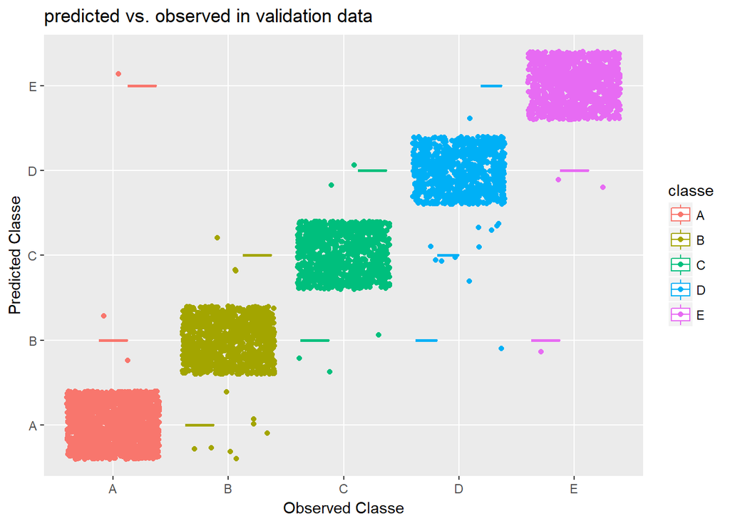

```r
qplot(classe, prdval, data=validation,  colour= classe, geom = c("boxplot", "jitter"), main = "predicted vs. observed in validation data", xlab = "Observed Classe", ylab = "Predicted Classe")
```

## Apply model to testing set

```r
prdvalT <- predict(modFitP, testingP)
#confusionMatrix(testingP$classe, prdvalT)
prdvalT
```

```
##  [1] B A B A A E D B A A B C B A E E A B B B
## Levels: A B C D E
```